# Take-home Exercise 3

Putting Visual Analytics into Practical Use

Ding Yanmu https://dingyanmu.netlify.app/  
May 10, 2022

# 1 Introduction

The task of Take-home Exercise 3 is to reveal the economic of the city of Engagement, Ohio USA by using appropriate static and interactive statistical graphics methods.

There are three questions will be answered in this blog.

- How does the financial health of the residents change over the period covered by the dataset?
- How do wages compare to the overall cost of living in Engagement?
- Are there groups that appear to exhibit similar patterns?

# 2 Data Discription

The data file used for this exercise is *FinancialJournal.csv*. This table contains information about financial transactions. Following are the definitions of 4 columns of data:

- **participantId** (integer): unique ID corresponding to the participant affected
- **timestamp** (datetime): the time when the check-in was logged
- **category** (string factor): a string describing the expense category, one of {“Education”, “Food”, “Recreation”, “RentAdjustment”, “Shelter”, “Wage”}
- **amount** (double): the amount of the transaction

# 3 Data Preparation

## 3.1 Installing and launching R packages

```r
packages <- c('tidyverse', 'lubridate', 'patchwork')

for(p in packages){
  if(!require(p, character.only = T)){
    install.packages(p)
  }
  library(p, character.only = T)
}
```

## 3.2 Importing the dataset

Data import was completed by using read_csv() which is a function in **readr** package. This function is useful for reading delimited files into a tibble. Here, head() function is used to display the first 6 rows of data in the dataset.

```r
raw_data <- read_csv("data/FinancialJournal.csv")
head(raw_data)
```

```
# A tibble: 6 x 4
  participantId timestamp           category  amount
          <dbl> <dttm>              <chr>      <dbl>
1             0 2022-03-01 00:00:00 Wage      2473.
2             0 2022-03-01 00:00:00 Shelter   -555.
3             0 2022-03-01 00:00:00 Education  -38.0
4             1 2022-03-01 00:00:00 Wage      2047.
5             1 2022-03-01 00:00:00 Shelter   -555.
6             1 2022-03-01 00:00:00 Education  -38.0
```

## 3.3 Data Preprocessing

### 3.3.1 Data Cleaning

When I used filter function in Excel to observe the data, I found that there are some identical data rows in the table. Therefore, I need to remove these duplicate data before visualizing the data. **raw_data %>% distinct()** in the following R code chunk is used to complete this step.

```r
data <- raw_data %>% distinct()
nrow(raw_data) - nrow(data)
```

```
[1] 1113
```

We can see that there are 1113 duplicate rows in the raw dataset.

### 3.3.2 Get participants’ average monthly income and average monthly outcome

Through analyzing the data in the **Participants.csv** table, I have already found that the number of participants in this study is fairly evenly distributed in five aspects: age, family size, whether there are children, education level, and interests.

Therefore, the trend in participants’ average monthly wages is a good indicator of financial health in Ohio state.

```r
num_participant <- max(data$participantId) - min(data$participantId) + 1

Month <- c()
Avg_wage <- c()
avg_food_list <- c()
Education_Expense <- c()
Recreation_Expense <- c()
Rental_Income <- c()
Rent_Cost <- c()
for (y in min(year(data$timestamp)):max(year(data$timestamp))){
  tmp <- data[year(data$timestamp) == y,]
  tmp_month <- month(tmp$timestamp)
  for (m in min(tmp_month):max(tmp_month)){
    y <- as.character(y)
    m <- as.character(m)
    Month <- append(Month, paste(y, m, sep = "-"))
    tmp_data <- tmp[month(tmp$timestamp) == m,]
    tmp_wage <- tmp_data[tmp_data$category == "Wage",]
    tmp_food <- tmp_data[tmp_data$category == "Food",]
    tmp_edu <- tmp_data[tmp_data$category == "Education",]
    tmp_rec <- tmp_data[tmp_data$category == "Recreation",]
    tmp_rent <- tmp_data[tmp_data$category == "RentAdjustment",]
    tmp_shel <- tmp_data[tmp_data$category == "Shelter",]
    Avg_wage <- append(Avg_wage, sum(tmp_wage$amount) / num_participant)
    avg_food_list <- append(avg_food_list, sum(tmp_food$amount) / num_participant)
    Education_Expense <- append(Education_Expense, sum(tmp_edu$amount) / num_participant)
    Recreation_Expense <- append(Recreation_Expense, sum(tmp_rec$amount) / num_participant)
    Rental_Income <- append(Rental_Income, sum(tmp_rent$amount) / num_participant)
    Rent_Cost <- append(Rent_Cost, sum(tmp_shel$amount) / num_participant)
  }
}

Engel_Coefficient <- avg_food_list / (avg_food_list + Education_Expense + Recreation_Expense + Rent_Cost)

month_fee_table <- data.frame(Month, Avg_wage, Engel_Coefficient, Education_Expense, Recreation_Expense, Rental_Income, Rent_Cost)
month_fee_table$Month<- factor(month_fee_table$Month,
                               levels = Month, ordered = TRUE)

head(month_fee_table)
```

```
   Month Avg_wage Engel_Coefficient Education_Expense
1 2022-3 6333.056         0.2019471         -14.19767
2 2022-4 3431.015         0.2404876         -11.29915
3 2022-5 3583.647         0.2570449         -11.29915
4 2022-6 3569.617         0.2550617         -11.29915
5 2022-7 3447.872         0.2586480         -11.29915
6 2022-8 3722.856         0.2629630         -11.29915
  Recreation_Expense Rental_Income Rent_Cost
1          -642.5230     52.921353 -624.7509
2          -385.4549      1.413694 -553.8265
3          -332.7578      0.000000 -552.3746
4          -311.3831      0.000000 -552.3746
5          -326.0269      0.000000 -552.3746
6          -303.6227      0.000000 -552.3746
```

# 4 Data visualization analysis

## 4.1 Trend of monthly average wages

Through observing the following bar chart, it is obvious that the per capita wage in March 2022 is nearly twice as large as the per capita wages in April 2022. I think the reason may be the outbreak of Omicron in Ohio in March 2022. The pandemic created a huge impact on economy of Ohio state, which led to a sharp drop in per capita income.

In 2023, although per capita wages will rebound in March, the overall trend will be still downward. Thus, I can initially infer that the Ohio residents’ financial health is not very good.

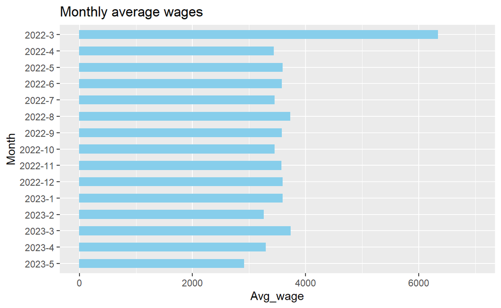

```r
p1 <- ggplot(data = month_fee_table, aes(x = Month, y = Avg_wage)) +
      geom_col(width = 0.5, color = "skyblue", fill = "skyblue") +
      ylim(0, 7000) +
      coord_flip() +
      scale_x_discrete(limits=rev(Month)) +
      ggtitle("Monthly average wages")
p1
```

## 4.2 Trend of Engel_Coefficient

According to the Engel coefficient standard designated by the United Nations, Ohio is still a wealthy area, but increasing 5 percentage in the Engel coefficient has already proved that the financial health in Ohio state is very unsatisfactory.

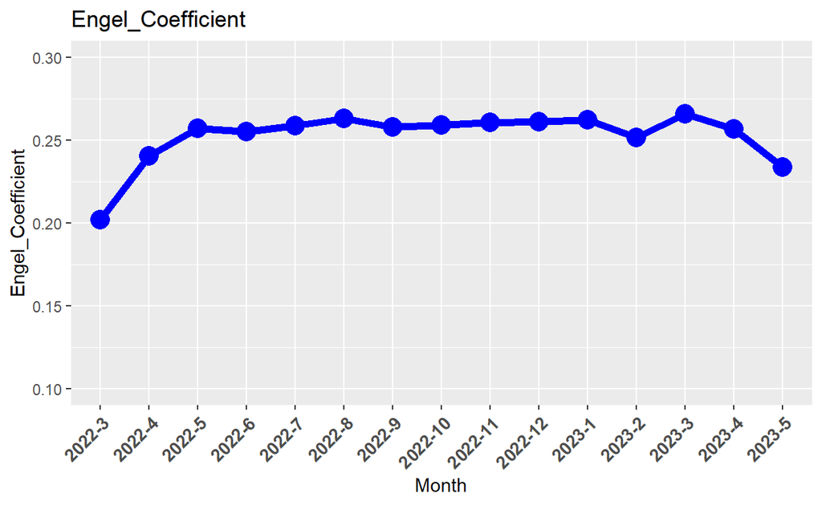

```r
p2 <- ggplot(data = month_fee_table, aes(x = Month, y = Engel_Coefficient)) +
      geom_point(colour=alpha('blue', 1), size=5) +
      geom_line(aes(group=1), colour=alpha('blue', 1), size=2) +
      ylim(0.1, 0.3) +
      theme(axis.text.x = element_text(angle = 45, hjust = 1, size = 10, face = "bold")) +
      ggtitle("Engel_Coefficient")
p2
```

## 4.3 Trends of rental income and rental cost

Through observing the following two charts, we can see that both average rental income and average rental cost fell down in April 2022. And both of them will not have obvious changing trend in the subsequent months. This is different from my guess that participants who have vacant homes may replenish their income by raising rents, which may cause renters to pay more money for the rent bills.

I guess the decline in rents may also be related to some economic policies published by the Ohio government. Obviously, such a situation is very beneficial to Ohio’s economic health, because it avoids to widen the gap between the rich and the poor. Moreover, reducing people’s housing pressure can also guarantee social stability.

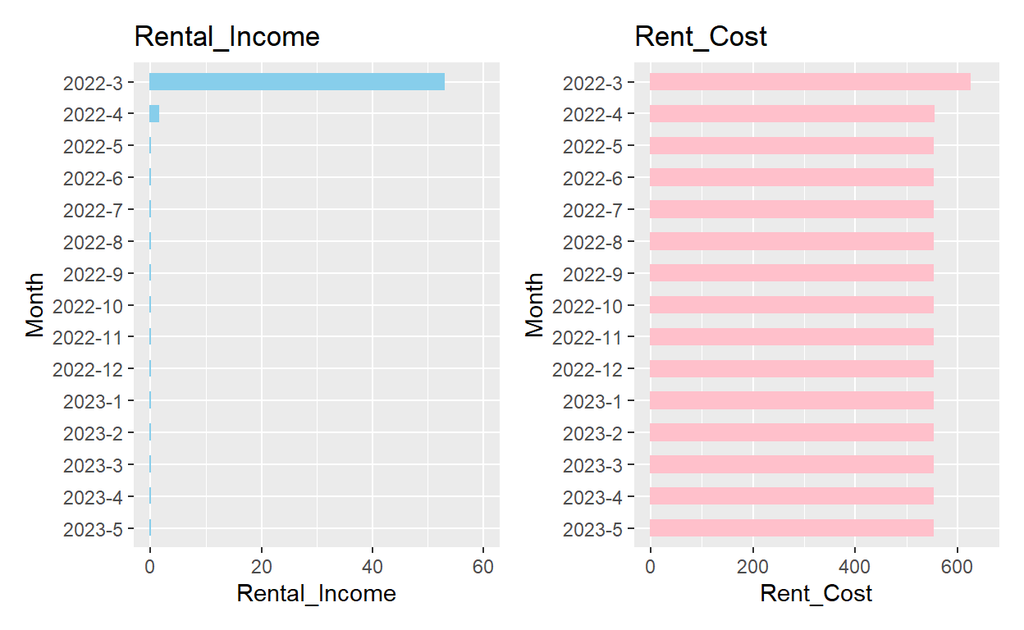

```r
p3 <- ggplot(data = month_fee_table, aes(x = Month, y = Rental_Income)) +
      geom_col(width = 0.5, color = "skyblue", fill = "skyblue") +
      ylim(0, 60) +
      coord_flip() +
      scale_x_discrete(limits=rev(Month)) +
      ggtitle("Rental_Income")

p4 <- ggplot(data = month_fee_table, aes(x = Month, y = abs(Rent_Cost))) +
      geom_col(width = 0.5, color = "pink", fill = "pink") +
      ylab("Rent_Cost") +
      ylim(0, 650) +
      coord_flip() +
      scale_x_discrete(limits=rev(Month)) +
      ggtitle("Rent_Cost")

p3 | p4
```

## 4.4 Trends of Recreation_Expense

Therefore, from the phenomenon that participants begin to reduce recreation cost, it is not difficult to find that the overall financial health in Ohio state has indeed got a certain impact.

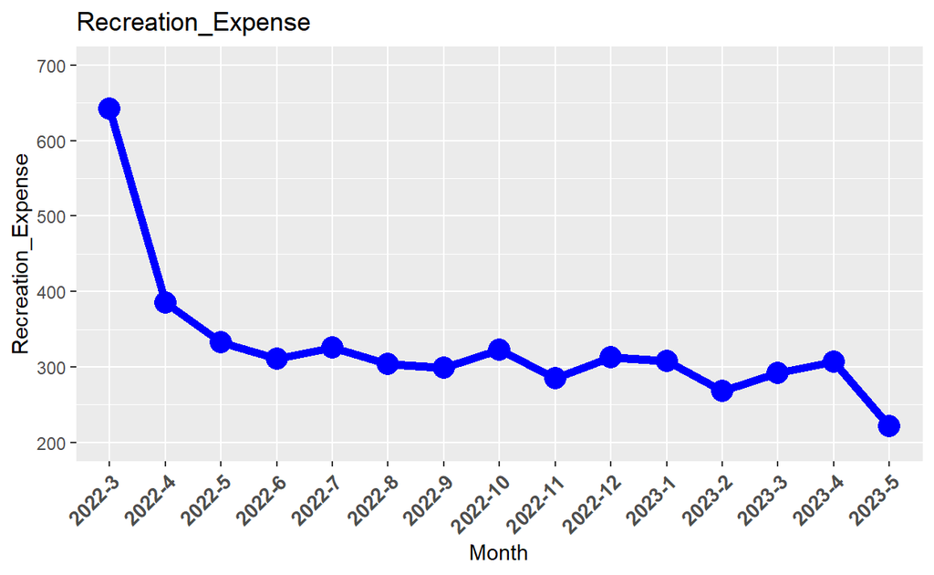

```r
p5 <- ggplot(data = month_fee_table, aes(x = Month, y = abs(Recreation_Expense))) +
      geom_point(colour=alpha('blue', 1), size=5) +
      geom_line(aes(group=1), colour=alpha('blue', 1), size=2) +
      ylab("Recreation_Expense") +
      ylim(200, 700) +
      theme(axis.text.x = element_text(angle = 45, hjust = 1, size = 10, face = "bold")) +
      ggtitle("Recreation_Expense")

p5
```

# 5 Conclusion

By analyzing the data in the `FinancialJournal.csv` file, we can draw the following three conclusions:

1. Under the influence of the pandemic or some other external factors, Ohio’s financial health has indeed suffered a certain impact.
2. Through the analysis of the Engel coefficient, it can be inferred that the Ohio government has indeed implemented a series of relevant policies to recover the economy to avoid further financial loss.
3. So far, it seems impossible to recover the economy in a short period. At least, all the financial loss cannot be recovered before May 2023.